# Przypadek IV

Przykłady modeli LR do rozdziału *Iloraz wiarygodności jako rekomendowane narzędzie weryfikacji hipotezy o wspólnym pochodzeniu dowodów rzeczowych

## Ocena jakości hybrydowych modeli LR

Efektywność modeli LR należy ocenić na podstawie wartości LR obliczonych dla wielu par próbek dowodowych i porównawczych, o których wiemy, iż pochodzą lub nie z tego samego źródła. W tym celu utworzono specjalny skrypt obliczenowy R hybridLR_comparison_research_code.R, dostępny w folderze IV. Egzekucja tego kodu wymaga kilku minut w zależności od mocy obliczeniowej komputera.

Poniżej krok po kroku przedstawiony został sposób policzenia wartości LR w celu oceny efektywności hybrydowego modelu LR, gdzie za pomocą metody rMANOVA redukuje się liczbę zmiennych, jednocześnie maksymalizując stosunek zmienności między- do wewnątrzobiektowej. LR obliczany jest więc na podstawie nowej zmiennej, utworzonej poprzez zrzutowanie danych oryginalnych na pierwszy kierunek wyznaczony z dekompozycji rMANOVA.

Poniżej kod ten rozbity jest na kilka istotnych fragmentów. Wiele z jego fragmentów powstało przez analogię do poprzednich przykładów (Przypadek I, II, III). Wszelkie modyfikacje związane są z tworzeniem zbiorów uczących oraz testowych przeprowadzonym zgodnie z procedurą opisaną w podrozdziale *Konstrukcja zbiorów uczących i testowych->Podział na zbiory uczące i testowe, gdy m<p*.

Na etapie ładowania pakietów oraz funkcji ponownie dodatkowo pojawia się funkcja rMANOVA_general_function() zapisana w pliku rMANOVA_general_function.R służąca do utworzenia nowych zmiennych na podstawie rMANOVA.

```r
source("../BW_function.R")
source("../LR_Nor_comparison_function.R")
source("../LR_KDE_comparison_function.R")
source("../rMANOVA_general_function.R")

if (!require("mvtnorm")) install.packages("mvtnorm")
```

Ładowanie danych z pliku zawierającego bazę danych (population). Dodatkowo wprowadzamy zmienną data.analysed, która będzie przechowywać oryginalną bazę danych, podczas gdy zmienna population zmienia się w zależności od porównywanych próbek.

```r
population = read.table(paste("../spectra_database.txt",sep=""),header=T)
data.analysed = population
```

Liczbę próbek zgromadzonych w bazie danych (M) oraz liczbę pomiarów dla każdej z nich (n.all) można uzyskać wpisując:

```r
M = length(unique(population$Name))
n.all=length(unique(population$Piece))

print(paste("liczba próbek w bazie danych = ",M));print(paste("liczba pomiarów dla próbek w bazie danych = ",n.all))
```

```
## [1] "liczba próbek w bazie danych =  20"
```

```
## [1] "liczba pomiarów dla próbek w bazie danych =  6"
```

Ze względu na losowy charakter tworzenia zbiorów uczących oraz testowych, tworzonych zgodnie z procedurą opisaną w podrozdziale *Konstrukcja zbiorów uczących i testowych->Podział na zbiory uczące i testowe, gdy m<p*, obliczenia prowadzi się kilkakrotnie w celu uniknięcia uzyskania zbyt pesymistycznych lub zbyt optymistycznych wyników. Liczba tych iteracji zdefiniowana jest w zmiennej validationSetsNo (tutaj validationSetsNo=5). Kilkukrotne obliczenia realizowane są dzięki pętli przebiegającej po s, iterującej po wartościach od 1 do validationSetsNo.

```r
validationSetsNo = 5
```

Wynikowe macierze (w przypadku założenia rozkładu normalnego output.matrix.Nor i output.matrix.KDE, gdy rozkład modelujemy przez KDE) będą zawierać wszystkie wartości LR dla każdej z par próbek dowodowych i porównawczych, gdzie rzędy odpowiadają próbkom dowodowym, a kolumny porównawczym. Macierze te zawierają więc liczbę rzędów i kolumn równą liczbie próbek w bazie danych. Macierze te mają również trzeci wymiar równy założonej maksymalnej liczbie iteracji (validationSetsNo).

```r
output.matrix.Nor = output.matrix.KDE = array(NA,c(M,M,validationSetsNo),dimnames=list(as.character(unique(population$Name)),as.character(unique(population$Name)),1:validationSetsNo))
```

Kolejno dane dla próbek zgromadzonych w bazie danych, jak i próbek dowodowych i porównawczych są dzielone zgodnie z procedurą opisaną w podrozdziale *Konstrukcja zbiorów uczących i testowych->Podział na zbiory uczące i testowe, gdy m<p*, Rys. 1.3 oraz 1.4. W poniższym fragmencie kodu poszczególne etapy oznaczone zostały za pomocą komentarzy ## zgodnie z notacją zamieszczoną w podrozdziale *Konstrukcja zbiorów uczących i testowych->Podział na zbiory uczące i testowe, gdy m<p* na Rys. 1.3 i 1.4. Każdy ze zbiorów A.1-A.3 powstaje z losowo wybranych dwóch spośród sześciu dostępnych pomiarów dla każdej z próbek z bazy danych. Komenda set.seed(s) jest dodana tutaj, by użytkownik uzyskał w przykładzie identyczne rezultaty, mimo, iż generowanie zbiorów testowych i uczących jest losowe. Usunięcie tej komendy (jak w skrypcie hybridLR_comparison_research_code.R) pozwala na powrót do całkowicie losowej generacji zbiorów.

Kolejne dwie zagnieżdzone pętle przebiegają po każdej próbce dowodowej (i) i porównawczej (j) i realizują obliczenia dla każdej możliwej pary próbek dowodowych i porównawczych. Wewnątrz tych pętli zagnieżdżona jest jeszcze jedna pętla przebiegająca po wszystkich submodelach (v), jakie rozpatrujemy. W przypadku rMANOVA LR liczony jest jedynie na pierwszym, najbardziej istotnym kierunku, stąd też jej zastosowanie jest niewielkie w tym przypadku.

Kolejnym etapem jest utworzenie próbek y.1 i y.2 oraz population zgodnie z założoną procedurą tworzenia zbiorów testowych i uczących opisaną w *Konstrukcja zbiorów uczących i testowych->Podział na zbiory uczące i testowe, gdy m<p*. Ze względu na nieustannie zmieniający się skład bazy danych w każdym porównaniu, konieczne jest obliczenie aktualnej liczby próbek, m oraz liczby ich pomiarów, n.

Kolejno liczymy macierze $\mathbf{W}$ i $\mathbf{B}$, średnią dla wszystkich próbek z bazy danych (x.mean ($\mathbf{\bar{x}}$)) oraz parametr wygładzający h.

Następnie obliczamy liczbę pomiarów dla próbek y.1 i y.2 (k.1 ($k_1$) i k.2 ($k_2$)) oraz ich średnie (y.mean.1 ($\mathbf{\bar{y}}_1$), y.mean.2 ($\mathbf{\bar{y}}_2$), y.star ($\mathbf{\bar{y}}^{*}$)).

Na podstawie zgromadzonych danych obliczamy wartości LR zakładając rozkład normalny średnich dla próbek w bazie danych (LR.Nor) lub modelując go za pomocą KDE (LR.KDE). Każda obliczona wartość zostaje wpisana do macierzy wynikowych (output.matrix.Nor i output.matrix.KDE).

```r
for (s in 1:validationSetsNo)
{
    tvec = NULL
    n.val = n.all/3
    for (g in 1:M)
    {set.seed(s);tvec = c(tvec,sample(rep(c(1,2,3),each=n.val)))}

    A.1 = data.analysed[which(tvec == 1),] ##etap 1 na Rys. 1.3 i 1.4
    A.1[,"Piece"] = rep(1:n.val,times=M)
    A.2 = data.analysed[which(tvec == 2),] ##etap 1 na Rys. 1.3 i 1.4
    A.2[,"Piece"] = rep(1:n.val,times=M)
    A.3 = data.analysed[which(tvec == 3),] ##etap 1 na Rys. 1.3 i 1.4
    A.3[,"Piece"] = rep(1:n.val,times=M)

    rMANOVA_res = rMANOVA_general_function(data=as.data.frame(A.1)) ##etap 2 na Rys. 1.4
    eigen_vectors_ij = rMANOVA_res$results
    center_ij = rMANOVA_res$center

    for (i in 1:M)
    {

        ##jeśli j/=i
        B = A.1[-which(A.1$Item == i),] ##etap 2 na Rys. 1.3
        B$Item = rep(1:(M-1),each=n.val)

        rMANOVA_res = rMANOVA_general_function(data=as.data.frame(B)) ##etap 3 na Rys. 1.3
        eigen_vectors_inotj = rMANOVA_res$results
        center_inotj = rMANOVA_res$center

        meanCentred_test_inotj = cbind(A.2[,c(1:3)],A.2[,-c(1:3)]-matrix(center_inotj,nrow=nrow(A.2),ncol=ncol(A.2)-3,byrow=T))
        projections_inotj = as.matrix(meanCentred_test_inotj[,-c(1:3)])%*%eigen_vectors_inotj ##etap 4 na Rys. 1.3

        P_inotj = cbind(A.2[,1:3],projections_inotj) ##etap 4 na Rys. 1.3

        ##jeśli j==i
        A = rbind(A.2,A.3[which(A.3$Item==i),]) ##etap 3 na Rys. 1.4
        A[,"Name"] = c(A.2[,3],rep(1000,times=n.val))
        A[,"Item"] = rep(1:(M+1),each=n.val)
        A[,"Piece"] = rep(1:n.val,times=M+1)

        meanCentred_test_ij = cbind(A[,c(1:3)],A[,-c(1:3)]-matrix(center_ij,nrow=nrow(A),ncol=ncol(A)-3,byrow=T))
        projections_ij = as.matrix(meanCentred_test_ij[,-c(1:3)])%*%eigen_vectors_ij ##etap 4 na Rys. 1.4

        P_ij = cbind(A[,1:3],projections_ij) ##etap 4 na Rys. 1.4

        for (j in 1:M)
        {
            if (i==j) P = P_ij else P = P_inotj

            vars = 1

            LR.final.Nor=LR.final.KDE = 1

            for (v in 1:length(vars))
            {
                variables = vars[v]+3
                p = length(variables)

                if (i==j)
                {
                    y.1 = P[which(P$Item == (M+1)),]
                    y.2 = P[which(P$Item == j),]

                    population = P[which(!P$Item %in% c(j,M+1)),]
                } else
                {
                    y.1 = P[which(P$Item==i),]
                    y.2 = P[which(P$Item==j),]

                    population = P[which(!P$Item %in% c(i,j)),]
                }

                n = length(unique(population$Piece))
                m = length(unique(population$Item))

                results.BW = BW(population=population,variables=variables,n=n,m=m)
                W = results.BW$W
                B = results.BW$B

                ifelse(p>1,x.mean<-colMeans(population[,variables]),x.mean<-mean(population[,variables]))

                h = (4/(m*(2*p+1)))^(1/(p+4))

                k.1 = length(y.1$Item)
                k.2 = length(y.2$Item)

                y.mean.1 = matrix(apply(as.matrix(y.1[,variables]), 2, mean), nrow = 1)
                y.mean.2 = matrix(apply(as.matrix(y.2[,variables]), 2, mean), nrow = 1)
                y.star = (k.1*y.mean.1+k.2*y.mean.2)/(k.1+k.2)

                results.LR.Nor = LR.Nor.function(y.mean.1, y.mean.2, y.star, x.mean, W, B, k.1, k.2) ##etap 5 na Rys. 1.3 i 1.4
                LR.Nor = results.LR.Nor$LR.Nor

                results.LR.KDE= LR.KDE.function(y.mean.1, y.mean.2, y.star, W, B, h, population, variables, p, k.1, k.2) ##etap 5 na Rys. 1.3 i 1.4
                LR.KDE = results.LR.KDE$LR.KDE

                LR.final.Nor=LR.final.Nor*LR.Nor
                LR.final.KDE=LR.final.KDE*LR.KDE
            }

            output.matrix.Nor[i,j,s] = LR.final.Nor
            output.matrix.KDE[i,j,s] = LR.final.KDE
        }
    }
}
```

Uzyskane macierze wynikowe można zapisać do plików hybridLR_comparison_research_Nor.txt oraz hybridLR_comparison_research_KDE.txt, które zostaną utworzone przez program i zapisane w folderze, w którym pracujemy. Pliki te można otworzyć za pomocą RStudio, jak w Przypadku III.

```r
saveRDS(output.matrix.Nor,file="hybridLR_comparison_research_Nor.txt")
saveRDS(output.matrix.KDE,file="hybridLR_comparison_research_KDE.txt")
```

Uzyskane wyniki LR służą do ustalenia efektywności modeli LR na podstawie poziomów wskazań fałszywie pozytywnych i fałszywie negatywnych oraz diagramów empiryczej entropii krzyżowej, ECE (podrozdział *Walidacja - ocena poprawności działania modeli LR*). Wyniki każdej z s iteracji stanowią macierz będącą jednym z tzw. slice macierzy trójwymiarowej. W każdej iteracji s wartości LR dla porównań, gdy H<sub>1</sub> jest prawdziwa (LR.H1.Nor i LR.H1.KDE) znajdują się na diagonali macierzy output.matrix.Nor i output.matrix.KDE. Elementy pozadiagonalne mieszczą natomiast wartości LR uzyskane, gdy H<sub>2</sub> jest prawdziwa (LR.H2.Nor i LR.H2.KDE). Warto zwrócić uwagę, że w hybrydowych modelach LR porównania nie są symetryczne. Oznacza to, że wynik LR dla porównania próbki 10 z 15 jest inny niż dla porównania próbki 15 z 10, ponieważ istotnym jest, która z próbek jest próbką dowodową, a która porównawczą już na etapie wykorzystania modelu chemometrycznego do uzyskania nowych zmiennych. Próbka porównawcza zawsze w tym etapie uczestniczy, a próbka dowodowa nie.  
Liczba odpowiedzi fałszywie pozytywnych (fp.Nor i fp.KDE) stanowi procentową liczbę wszystkich wartości LR powyżej jedności spośród tych obliczonych, gdy H<sub>2</sub> jest prawdziwa. Liczba odpowiedzi fałszywie negatywnych (fn.Nor i fn.KDE) stanowi liczbę wszystkich wartości LR poniżej jedności spośród tych obliczonych, gdy H<sub>1</sub> jest prawdziwa. Wartości te podane są w macierzy wynikowej error_rates, gdzie w rzędach kolejno mieszczą się wartości fp.Nor, fp.KDE, fn.Nor, fn.KDE, a kolumny odpowiadają kolejnym iteracjom s. Macierz ta zapisana zostanie do pliku utworzonego przez program i zapisanego w folderze, w którym pracujemy, hybridLR_comparison_research_error_rate.txt.

Diagramy ECE można narysować na podstawie poniższego fragmentu kodu wykorzystującego funkcję ECE_plot() zapisaną w osobnym pliku ECE_function.R. Powstałe grafiki zapisane zostaną do plików .png, utworzonych przez program i zapisanych w folderze, w którym pracujemy. W nazwach plikóW pojawi sie numer iteracji s, np. hybridLR_comparison_research_Nor_ECE_s1.png., hybridLR_comparison_research_KDE_ECE_s1.png.

```
##               1        2        3         4         5
## fp_Nor 38.42105 7.368421 11.31579  5.789474  9.736842
## fp_KDE 36.05263 7.631579 11.05263  5.789474  9.736842
## fn_Nor  5.00000 0.000000  0.00000 25.000000 25.000000
## fn_KDE  5.00000 0.000000  0.00000 25.000000 25.000000
```

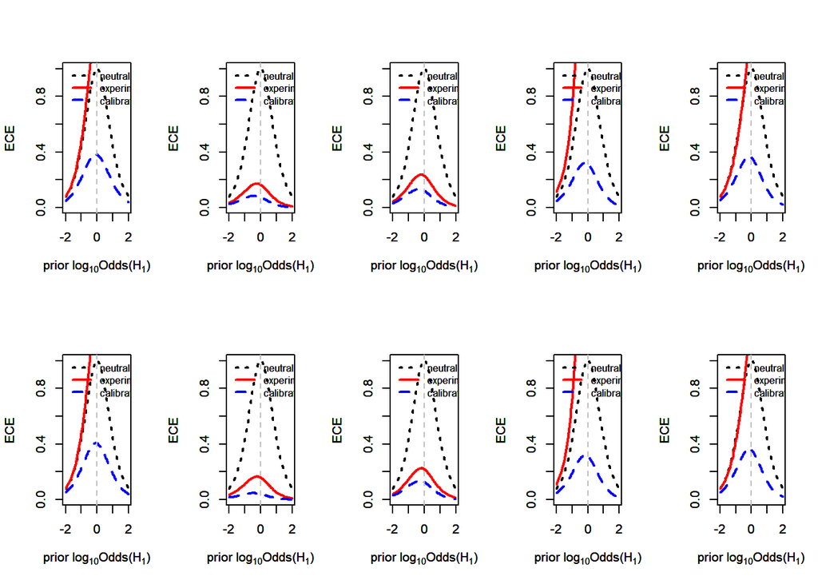

```r
error_rates = matrix(0, nrow = 4, ncol = validationSetsNo,dimnames=list(c("fp_Nor", "fp_KDE", "fn_Nor", "fn_KDE"),1:validationSetsNo))
source("../ECE_function.R")

for (ss in 1:validationSetsNo)
{
  true.H1.Nor = diag(output.matrix.Nor[,,ss])
  true.H2.Nor = output.matrix.Nor[,,ss][row(output.matrix.Nor[,,ss])!=col(output.matrix.Nor[,,ss])]
  true.H1.KDE = diag(output.matrix.KDE[,,ss])
  true.H2.KDE = output.matrix.KDE[,,ss][row(output.matrix.KDE[,,ss])!=col(output.matrix.KDE[,,ss])]
  fn.Nor = length(which(true.H1.Nor<1))/M*100
  fp.Nor = length(which(true.H2.Nor>1))/(M*(M-1))*100
  fn.KDE = length(which(true.H1.KDE<1))/M*100
  fp.KDE = length(which(true.H2.KDE>1))/(M*(M-1))*100

  error_rates[1,ss] = fp.Nor
  error_rates[2,ss] = fp.KDE
  error_rates[3,ss] = fn.Nor
  error_rates[4,ss] = fn.KDE

  write.table(signif(error_rates, digits = 3), file="hybridLR_comparison_research_error_rate.txt", quote = FALSE, sep = "\t")

  ECE_results = ECE_plot(true.H1.Nor,true.H2.Nor)
  dev.copy(png,paste("hybridLR_comparison_research_Nor_ECE_s",ss,".png",sep=""));dev.off()

  ECE_results = ECE_plot(true.H1.KDE,true.H2.KDE)
  dev.copy(png,paste("hybridLR_comparison_research_KDE_ECE_s",ss,".png",sep=""));dev.off()
}
print(error_rates)
```

**INTERPRETACJA: Poziomy odpowiedzi fałszywie pozytywnych (do ok. 11%) oraz fałszywie negatywnych (brak) dla drugiej i trzeciej teracji są akceptowalne. Dla pozostałych iteracji model dostarcza dużej liczby odpowiedzi fałszywych. Rezultat ten pokazuje, jak istotne jest wielokrotne losowanie zbiorów uczących oraz testowych (nawet więcej niż 5-krotnie). Wszelkie algorytmy dokonujące wyboru danych do zbiorów uczących i testowych (np. algorytm duplex czy Kennarda Stone’a) nie są tu przydatne, ponieważ każdorazowo losuje się dane sposród zaledwie 6 pomiarów. W takiej sytuacji algorytm też będzie mało obiektywny, a wyniki dość przypadkowe. Diagramy ECE również wskazują, że analizowany model LR w drugiej i trzeciej iteracji z reguły wspiera prawidłowe hipotezy, a wsparcie to jest znaczące. Wsparcie dla błędnych hipotez pojawia się sporadycznie i nie jest duże. Niemniej jednak widoczny jest brak stabilności modelu, co można zredukować poprzez wielokrotne losowanie zbiorów uczących i testowych. Ponadto kluczowym staje się też pytanie, który z modeli jest lepszy, ten oparty o rozkład normalny, czy KDE? W tym przypadku oba modele dają porównywalne rezultaty (odpowiadające sobie wartości LR w obu modelach są zbliżone). W razie rozbieżności bardziej adekwatny powinien okazać się model bazujący na KDE, ponieważ rozkład modelowany empirycznie jest bliższy rzeczywistości niż założony rozkład normalny. Innym sposobem jest też wykorzystanie testów istotości, które pozwalają na ustalenie, czy dane użyte do modelu mogą pochodzić z rozkładu normalnego.**